# Big Cojo Cam

Ryan Wang

2023-07-19

### Big Cojo Cam - Plotting and Analyzing the Time Series

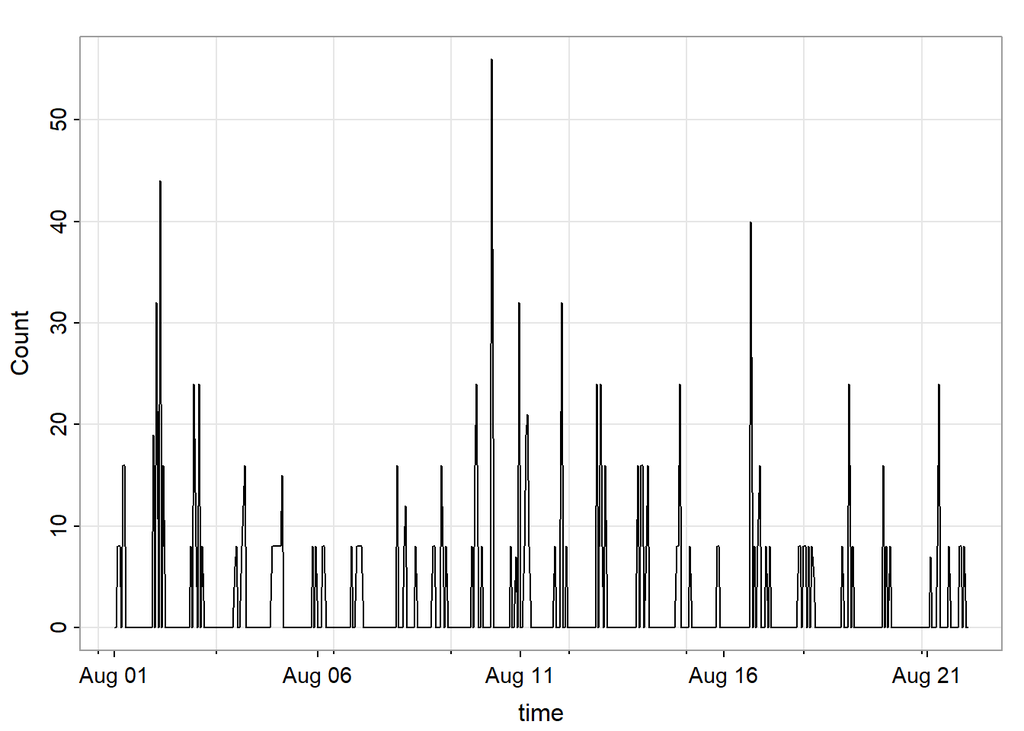

```r
# take a subset for analysis
# and split into training and testing set.

bc_hour_ts_total_1 <- ts(bc_hour_complete$number_of_objects[(19):(19+504+12)], frequency = 24)
bc_hour_ts_train_1 <- ts(bc_hour_complete$number_of_objects[(19):(19+504)], frequency = 24)
bc_hour_ts_test_1 <-
  ts(bc_hour_complete$number_of_objects[(524):(524+12)], frequency = 24, start = c(22, 1))


time_bc_hour_ts_train <- strptime(bc_hour_complete$time[(19):(504+19)], "%m/%d/%Y %H:%M")
tsplot(x=time_bc_hour_ts_train, y=bc_hour_ts_train_1, xlab = 'time', ylab = 'Count')
```

The variance of the time series seems to be constant, so the box cox transformation is not necessary.

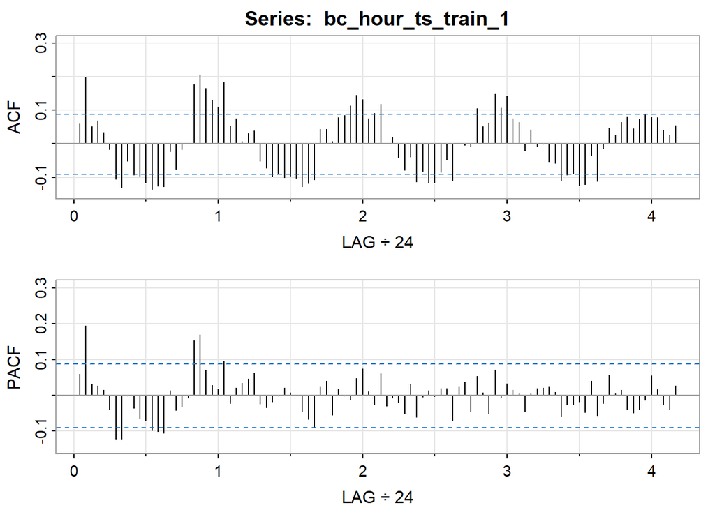

```
##      [,1] [,2] [,3] [,4] [,5]  [,6]  [,7]  [,8]  [,9] [,10] [,11] [,12] [,13]
## ACF  0.06 0.20 0.05 0.07 0.03 -0.02 -0.11 -0.13 -0.05 -0.09 -0.10 -0.12 -0.14
## PACF 0.06 0.19 0.03 0.03 0.02 -0.04 -0.12 -0.12  0.00 -0.04 -0.06 -0.07 -0.10
##      [,14] [,15] [,16] [,17] [,18] [,19] [,20] [,21] [,22] [,23] [,24] [,25]
## ACF  -0.13 -0.13 -0.02 -0.08 -0.02  0.00  0.18  0.20  0.16  0.13  0.11  0.18
## PACF -0.10 -0.11  0.01 -0.04 -0.03 -0.01  0.15  0.17  0.07  0.03  0.02  0.09
##      [,26] [,27] [,28] [,29] [,30] [,31] [,32] [,33] [,34] [,35] [,36] [,37]
## ACF   0.05  0.07  0.01  0.03  0.04 -0.05 -0.07 -0.10 -0.09 -0.10 -0.10  -0.1
## PACF -0.02  0.02  0.03  0.05  0.06 -0.02 -0.03 -0.02  0.00  0.02  0.01   0.0
##      [,38] [,39] [,40] [,41] [,42] [,43] [,44] [,45] [,46] [,47] [,48] [,49]
## ACF  -0.13 -0.12 -0.11  0.04  0.04  0.01  0.08  0.08  0.11  0.14  0.13  0.07
## PACF -0.05 -0.07 -0.09  0.03  0.04 -0.06  0.02  0.00 -0.01  0.05  0.07  0.01
##      [,50] [,51] [,52] [,53] [,54] [,55] [,56] [,57] [,58] [,59] [,60] [,61]
## ACF   0.09  0.12  0.00  0.02 -0.04 -0.08 -0.04 -0.11 -0.08 -0.12 -0.12 -0.09
## PACF -0.03  0.06 -0.03 -0.01 -0.02 -0.05  0.03 -0.06  0.00  0.01  0.00  0.02
##      [,62] [,63] [,64] [,65] [,66] [,67] [,68] [,69] [,70] [,71] [,72] [,73]
## ACF  -0.05 -0.11  0.00  0.00 -0.01  0.10  0.05  0.06  0.15  0.11  0.14  0.08
## PACF  0.02 -0.07  0.02  0.04 -0.05  0.05  0.01 -0.05  0.07 -0.01  0.03  0.01
##      [,74] [,75] [,76] [,77] [,78] [,79] [,80] [,81] [,82] [,83] [,84] [,85]
## ACF   0.06 -0.02  0.04 -0.01  0.00 -0.05 -0.06 -0.11 -0.09 -0.09 -0.12 -0.12
## PACF  0.00 -0.05  0.00  0.02  0.02  0.02  0.01 -0.06 -0.03 -0.03 -0.02 -0.05
##      [,86] [,87] [,88] [,89] [,90] [,91] [,92] [,93] [,94] [,95] [,96] [,97]
## ACF  -0.04 -0.11 -0.01  0.05  0.03  0.06  0.08  0.04  0.07  0.09  0.08  0.08
## PACF  0.04 -0.06 -0.02  0.06  0.00  0.01 -0.04 -0.05 -0.04 -0.01  0.06  0.02
##      [,98] [,99] [,100]
## ACF   0.04  0.03   0.05
## PACF -0.03 -0.04   0.03
```

```r
acf2(bc_hour_ts_train_1, max.lag = 100)
```

The ACF plot shows significant spikes at seasonal lags, which is a sign of seasonality. The seasonality can be removed by differencing.

Differencing is a technique to remove the trend or seasonality from a time series data. It involves calculating the difference between consecutive observations to create a new series

First Difference (d = 1): To remove a trend, you take the difference between each observation and its previous observation. This is called first-order differencing: $y_t' = y_t - y_{t-1}$

The new series, y_t’, will have one less observation than the original series, as the first observation is dropped due to the differencing operation.

Second Difference (d = 2): If the first difference still contains a trend or is not yet stationary, you can take the difference between each observation of the first-differenced series and its previous observation. This is called second-order differencing: $y_t'' = y_t' - y_{t-1}'$

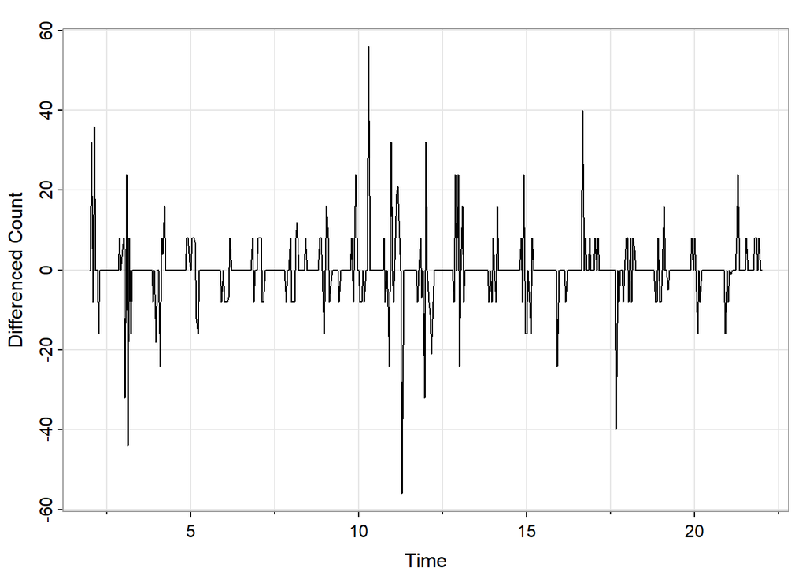

```r
diff_bc_hour_ts_train <- diff(bc_hour_ts_train_1, 24)
tsplot(diff_bc_hour_ts_train, ylab = "Differenced Count")
```

```r
adf.test(diff_bc_hour_ts_train)
```

```
##
##  Augmented Dickey-Fuller Test
##
## data:  diff_bc_hour_ts_train
## Dickey-Fuller = -9.3566, Lag order = 7, p-value = 0.01
## alternative hypothesis: stationary
```

```r
Box.test(diff_bc_hour_ts_train, lag = 24, type = c("Box-Pierce"), fitdf = 0)
```

```
##
##  Box-Pierce test
##
## data:  diff_bc_hour_ts_train
## X-squared = 179.16, df = 24, p-value < 2.2e-16
```

To further confirm that the time series is stationary, I perform the ADF test. To ensure that the stationary time series is not a white noise so that the modelling is meaningful, I perform the Box-Pierce test.

The p-value of both tests are less than 0.05, and thus we can reject the null hypothesis and take that the series is not a white noise and stationary.

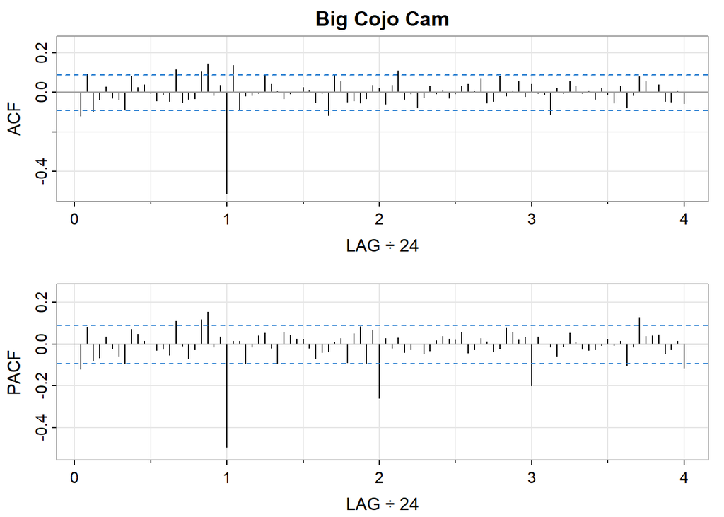

```
##       [,1] [,2]  [,3]  [,4] [,5]  [,6]  [,7]  [,8] [,9] [,10] [,11] [,12] [,13]
## ACF  -0.12 0.09 -0.10 -0.04 0.03 -0.03 -0.04 -0.09 0.08  0.03  0.04 -0.01 -0.04
## PACF -0.12 0.08 -0.08 -0.07 0.03 -0.02 -0.06 -0.09 0.07  0.05  0.01  0.00 -0.03
##      [,14] [,15] [,16] [,17] [,18] [,19] [,20] [,21] [,22] [,23] [,24] [,25]
## ACF  -0.01 -0.05  0.12 -0.05 -0.03 -0.03  0.11  0.14 -0.02  0.04 -0.51  0.14
## PACF -0.02 -0.05  0.11 -0.01 -0.07 -0.03  0.12  0.15 -0.01  0.04 -0.49  0.01
##      [,26] [,27] [,28] [,29] [,30] [,31] [,32] [,33] [,34] [,35] [,36] [,37]
## ACF  -0.09 -0.02 -0.02 -0.01  0.09  0.04  0.01 -0.03 -0.01  0.00  0.03  0.01
## PACF  0.01 -0.09 -0.01  0.04  0.05 -0.02 -0.09  0.06  0.04  0.02  0.02 -0.02
##      [,38] [,39] [,40] [,41] [,42] [,43] [,44] [,45] [,46] [,47] [,48] [,49]
## ACF  -0.05  0.00 -0.12  0.09  0.06 -0.05 -0.04 -0.05 -0.03  0.03  0.02 -0.06
## PACF -0.07 -0.04 -0.04  0.01  0.03 -0.09  0.05  0.08 -0.09  0.07 -0.26  0.03
##      [,50] [,51] [,52] [,53] [,54] [,55] [,56] [,57] [,58] [,59] [,60] [,61]
## ACF   0.04  0.11 -0.03 -0.01 -0.08 -0.03  0.03 -0.01  0.01 -0.03 -0.01  0.03
## PACF -0.02  0.03 -0.04 -0.03  0.00 -0.04 -0.03  0.02  0.04  0.02  0.02  0.06
##      [,62] [,63] [,64] [,65] [,66] [,67] [,68] [,69] [,70] [,71] [,72] [,73]
## ACF   0.04  0.01  0.07 -0.05 -0.05  0.08 -0.02  0.01  0.06 -0.02  0.04  0.00
## PACF -0.04 -0.03  0.03  0.01 -0.04 -0.02  0.08  0.06  0.02  0.03 -0.20  0.04
##      [,74] [,75] [,76] [,77] [,78] [,79] [,80] [,81] [,82] [,83] [,84] [,85]
## ACF  -0.01 -0.11  0.02  0.00  0.05  0.03  0.00  0.01 -0.04  0.02 -0.01 -0.05
## PACF  0.00 -0.01 -0.06 -0.01  0.05  0.01 -0.02 -0.03 -0.03 -0.01  0.02 -0.01
##      [,86] [,87] [,88] [,89] [,90] [,91] [,92] [,93] [,94] [,95] [,96]
## ACF   0.03 -0.08 -0.02  0.08  0.05  0.00  0.04 -0.05 -0.05  0.01 -0.06
## PACF  0.02 -0.10 -0.01  0.13  0.04  0.04  0.05 -0.04 -0.03  0.02 -0.12
```

```r
acf2(diff_bc_hour_ts_train, main = "Big Cojo Cam" )
```

PACF also shows a geometric decay over both seasonal and the non-seasonal lags, which could be a sign of Moving average and seasonal moving average.

Since it is a ARMA(SARMA) process , the exact values of p and q cannot be determined with the ACF/PACF plots.